# COMPSCIX 415.2 Homework 3

Sharmistha Maitra

2/13/2018

```r
library(nycflights13)
library(tidyverse)
```

# 3.8.1 Exercises

## 1.What is the problem with this plot? How could you improve it?

## Answer: The problem with this plot is the selection of the variables for the x axis and the y-axis, highway mileage (hwy) vs city mileage (cty) doesnt give any insight into the mileage performance of vehicles in terms of their displ, drive , class or other category . This plot can be improved by graphing (ctw vs displ, hwy vs displ) .

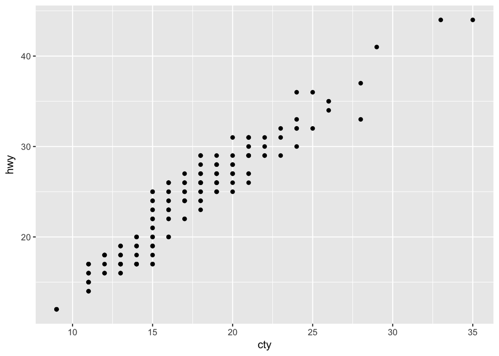

```r
ggplot(data = mpg, mapping = aes(x = cty, y = hwy)) +
  geom_point()
```

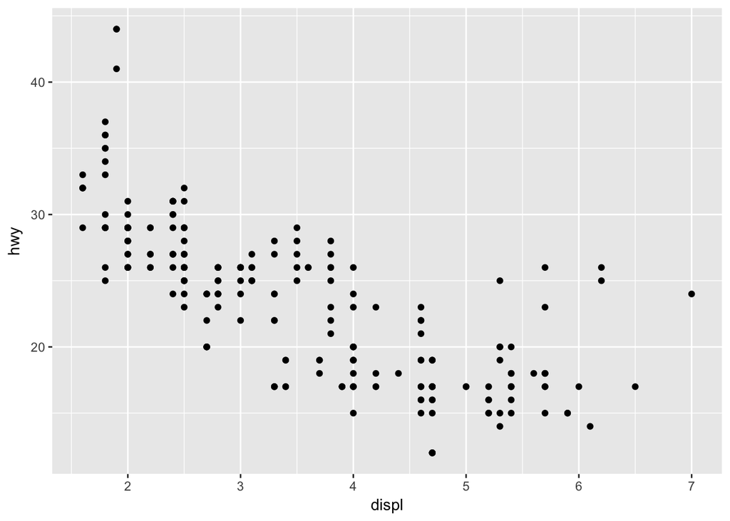

```r
ggplot(data = mpg, mapping = aes(x = displ, y = hwy)) +
  geom_point()
```

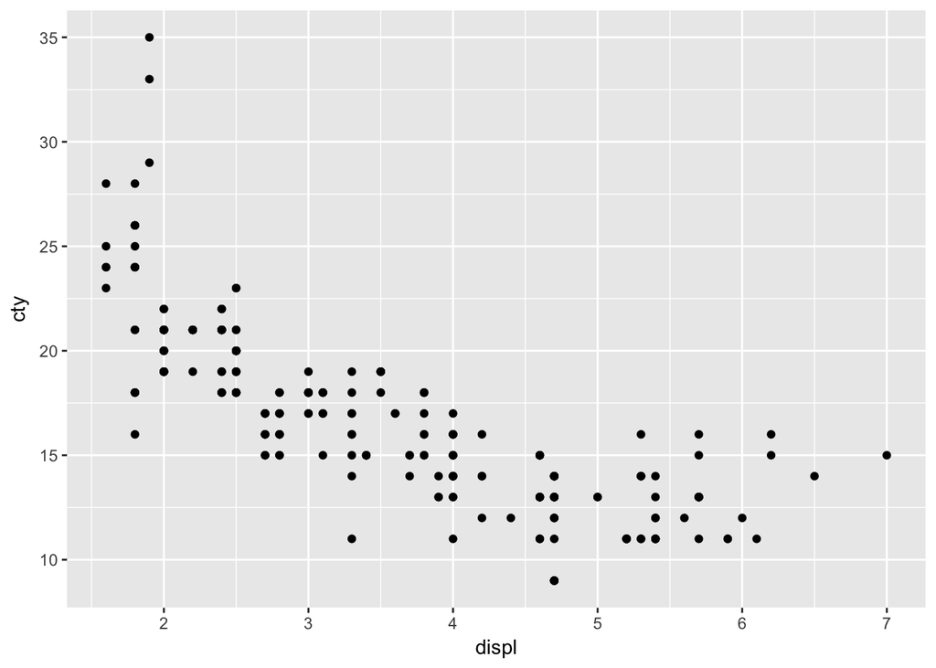

```r
ggplot(data = mpg, mapping = aes(x = displ, y = cty)) +
  geom_point()
```